# **Week 2 Short Answer Questions**

## Yunjae Choi

Compiled on Tue Mar 14 22:47:58 2017.

### Chapter 1

##### Problem 1.1

1. 3
2. 2
3. 1
4. 1
5. 2

##### Problem 1.2

```
The table is not "tidy" in that the cases within each of the variables are not in the same format. They have to be in a uniform format in order for R to do operations on our commands. For example, all names can be in one form: "Last name, First name," or "First name Last name," but not both.
```

##### Problem 1.4

1. What are the variables in each table?
   - Data Table A: Year, Algeria, Brazil, Columbia
   - Data Table B: Country, Y2000, Y2001
   - Data Table C: Country, Year, Value
2. What is the meaning of a case for each table?
   - Data Table A: A year
   - Data Table B: A country
   - Data Table C: A country in a year

##### Problem 1.5

1. How many variables are there?

   ```
   8
   ```

2. What do the cases represent?

   ```
   Airport names in FAA airport code
   ```

3. For each variable, make a reasonable guess about whether the values will be numerical or quantitative.

   ```
   * faa - categorical
   * name - categorical
   * lat - quantitative
   * lon - quantitative
   * alt - quantitative
   * tz - quantitative
   * dst - categorical
   * tzone - categorical
   ```

##### Problem 2.2

```
file name
```

##### Problem 2.3

```r
# install.packages("mosaicData")
# data(data = CPS85, package = "mosaicData")
# help(CPS85, package = "mosaicData")
```

[output not shown]

##### Problem 2.4

```
    the data name cannot be the same as the package name. A package contains a number of data. The package here should be where NHANES comes from.
```

##### Problem 2.6

1. OK
2. Wrong

   ```
   a dash (-) is not one of the allowed punctuation marks in an object name.
   ```

3. Wrong

   ```
   Being in quotes, "MyData" is a constant, not an object name.
   ```

4. OK
5. Wrong

   ```
   a space is not allowed in an object name
   ```

6. OK
7. OK
8. OK
9. Wrong

   ```
   parentheses not allowed
   ```

##### Problem 2.7

Installing done above.

```r
data(flights, package = "nycflights13")
```

1. How many variables are there?

```r
ncol(flights)
```

```
## [1] 19
```

2. How many cases are there?

```r
nrow(flights)
```

```
## [1] 336776
```

3. What is the meaning of a case? (“Meaning” refers to the kind of entity, for instance, “airport” or “airline” or “date”. Hint: the case in flights is not any of these things.) On-time data for all flights that departed NYC (i.e. JFK, LGA or EWR) in 2013.

   ```
   To look up the meanings of variables:
   ```

```r
# Help(flights)
```

4. For each variable, is the variable quantitative or categorical?

```r
str(flights)
```

```
## Classes 'tbl_df', 'tbl' and 'data.frame':    336776 obs. of  19 variables:
##  $ year          : int  2013 2013 2013 2013 2013 2013 2013 2013 2013 2013 ...
##  $ month         : int  1 1 1 1 1 1 1 1 1 1 ...
##  $ day           : int  1 1 1 1 1 1 1 1 1 1 ...
##  $ dep_time      : int  517 533 542 544 554 554 555 557 557 558 ...
##  $ sched_dep_time: int  515 529 540 545 600 558 600 600 600 600 ...
##  $ dep_delay     : num  2 4 2 -1 -6 -4 -5 -3 -3 -2 ...
##  $ arr_time      : int  830 850 923 1004 812 740 913 709 838 753 ...
##  $ sched_arr_time: int  819 830 850 1022 837 728 854 723 846 745 ...
##  $ arr_delay     : num  11 20 33 -18 -25 12 19 -14 -8 8 ...
##  $ carrier       : chr  "UA" "UA" "AA" "B6" ...
##  $ flight        : int  1545 1714 1141 725 461 1696 507 5708 79 301 ...
##  $ tailnum       : chr  "N14228" "N24211" "N619AA" "N804JB" ...
##  $ origin        : chr  "EWR" "LGA" "JFK" "JFK" ...
##  $ dest          : chr  "IAH" "IAH" "MIA" "BQN" ...
##  $ air_time      : num  227 227 160 183 116 150 158 53 140 138 ...
##  $ distance      : num  1400 1416 1089 1576 762 ...
##  $ hour          : num  5 5 5 5 6 5 6 6 6 6 ...
##  $ minute        : num  15 29 40 45 0 58 0 0 0 0 ...
##  $ time_hour     : POSIXct, format: "2013-01-01 05:00:00" "2013-01-01 05:00:00" ...
```

```r
class(flights$time_hour) # this can be considered a string
```

```
## [1] "POSIXct" "POSIXt"
```

5. For the variables air_time and distance, what are the units?

   ```
   minutes
   ```

```r
# Help(flights)
```

##### Problem 2.8

“<–” indicates to what it should be changed.

1. ralph <- sqrt 10

   ```
   3
   ```

2. ralph2 <– “Hello to you!”

   ```
   1
   ```

3. 3ralph <- “Hello to you!”

   ```
   4
   ```

4. ralph4 <- “Hello to you!

   ```
   2
   ```

5. ralph5 <- date()

   ```
   5
   ```

##### Problem 2.9

1. “.” and “_"
2. All of them

##### Problem 2.10

```r
data(data = CountryData, package = "DataComputing")
ncol(CountryData)
```

```
## [1] 76
```

2. mass of trunk fat

```r
# help(NCHS, package = "DataComputing")
```

```r
data(data = WorldCities, package = "DataComputing")
nrow(WorldCities)
```

```
## [1] 23018
```

4. Count

```r
data(data = BabyNames, package = "DataComputing")
head(BabyNames)
```

```
##        name sex count year
## 1      Mary   F  7065 1880
## 2      Anna   F  2604 1880
## 3      Emma   F  2003 1880
## 4 Elizabeth   F  1939 1880
## 5    Minnie   F  1746 1880
## 6  Margaret   F  1578 1880
```

```r
data(RegisteredVoters, package = "DataComputing")
levels(RegisteredVoters$party)
```

```
## [1] "DEM" "LIB" "REP" "UNA"
```

##### Problem 3.1

1. data frame (fireplace)

   Put it at the start of a chain, e.g. fireplace %>% nrow()

```r
fireplace <- data.frame(c(1,2,3,4,5), row.names = 1,4,36)
fireplace
```

```
##   X4 X36
## 1  4  36
## 2  4  36
## 3  4  36
## 4  4  36
## 5  4  36
```

2. a function (b)

   In this case, “sqrt” is a function; Follow it by an open parenthesis, fileplace(
3. the name of a named argument (c)

   “BabyNames” is the name of a named argument, “data”; Follow it by = inside the parentheses of a function, e.g., fun(fileplace = 7)
4. a variable (d)

   “sex” in “BabyNames”; place it inside the parentheses of a function, but not in the position of the name of a named argument, e.g., fun(fileplace) or fun(x = fireplace)

##### Problem 3.2

```
"Result <- %>% filter(BabyNames, name=="Prince")" is illegitimate because there's no data frame that the filter function is being applied to. It should be
```

```r
library("magrittr")
Result <-
  BabyNames %>%
  filter(name == "Prince")
```

##### Problem 3.3

```
A package contains many data set. Therefore, NHANES cannot be the package for this particular data set, "NHANES"
```

```r
# help(NHANES, package <- "NHANES")
```

##### Problem 3.4

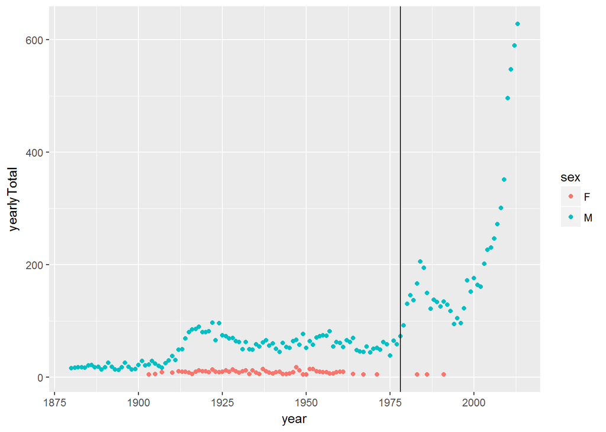

```r
# BabyNames = data(data = BabyNames, package = "DataComputing")

Princes <-
  BabyNames %>%
  filter(name == "Prince") %>%
  group_by(year, sex) %>%
  summarise(yearlyTotal = sum(count))

# Now graph it!
Princes %>%
  ggplot(aes(x = year, y = yearlyTotal)) +
  geom_point(aes(color = sex)) +
  geom_vline(xintercept = 1978)
```

1. b
2. a
3. c
4. a
5. a
6. c
7. c
8. a
9. d
10. a
11. c?
12. a
13. a
14. c
15. c
16. a
17. d
18. a
19. d

##### Problem 3.5

```r
data(msleep, package = "ggplot2")
# help(msleep)
nrow(msleep)
```

```
## [1] 83
```

1. brainwt. brain weight in kilograms
2. 83
3. number of observations in the data
4. carnivore, omnivore or herbivore

##### Problem 3.6

```
Statement (c) is different. Rather than calculating the total number of births (using sum()), it finds the mean number of births across all the cases in each year/sex group.
```

### Chapter 4

##### Problem 4.1

1. italics: *one*
2. bold face: **two**
3. bullet point:

   ```
   * three
   ```

4. biggest size of the headings

# Four

5. it would just print out ‘five’

`five`

6. “Six” that is of a smaller size than the biggest size “#”

## Six

7. text “seven” that takes us to the following link

[seven](http://tiny.cc/dcf/index.html)

##### Problem 4.2

1. not correct “`” mark
2. not correct “`” mark
3. need 3 “`” marks each in the beginnning and end
4. need parallel marks (in two lines)
5. need 3 “`” marks each in the beginnning and end

##### Problem 4.3

### An Introduction

Arithmetic is *easy*! For instance

```r
3 + 2
```

```
## [1] 5
```

The above heading will be in bigger font than the rest. The text “easy” will be italicized. 3 + 2 will appear in the calculated form 5.

##### Problem 4.4

1. a possible URL
2. a possible file
3. neither
4. a possible URL
5. neither
6. a possible file

##### Problem 4.5

Done on a separate file Birds.Rmd